# Homework1

Nilüfer Çetin - IE360 - Fall 2020

07 11 2020

# Data Visualization and Google Trends on Three Different Measures from Turkey

## 1) Monthly Housing Data of Turkey over 2013-2020

This measure’s data set consists of monthly reported values of number of houses sold in Turkey. The data is taken between 2013 and 2020, however since the year 2020 has not ended yet, unfortunately, the last observation was September 2020. Aside from monthly observations, the number of houses sold were separated to cities where the house sold was located. More information about the data can be found in the [TUIK web-site source](https://data.tuik.gov.tr/Kategori/GetKategori?p=Insaat-ve-Konut-116).

Since there were numbers for every city in Turkey, the data was huge and to narrow it down “Total Number of Houses Sold in Turkey” is selected as the measure. After the necessary manipulations, the dataset that include number of monthly sold houses in Ankara, İstanbul and Turkey total were obtained. If we look at the head of this data frame,

```
##       Loc   Sold       Date
## 1 Türkiye  87444 2013-01-15
## 2 Türkiye  88519 2013-02-15
## 3 Türkiye  97956 2013-03-15
## 4 Türkiye  95381 2013-04-15
## 5 Türkiye 103261 2013-05-15
## 6 Türkiye  96424 2013-06-15
```

It can be seen that there is a date column that shows every month’s 15th day. Normally, these values are collected for the whole month and what is meant by 15-01-2013 is the time horizon January 2013 as a month. This date is added since it is easier to plot with the full date and the interpretation of the end or the beginning of the month can be misleading. Moreover, although the aim is to visualize Turkey as a whole, İstanbul and Ankara were taken as separate locations to see the extent of how the trends in these megacities are in relation to Turkey.

If we plot all the observations with respect to time,

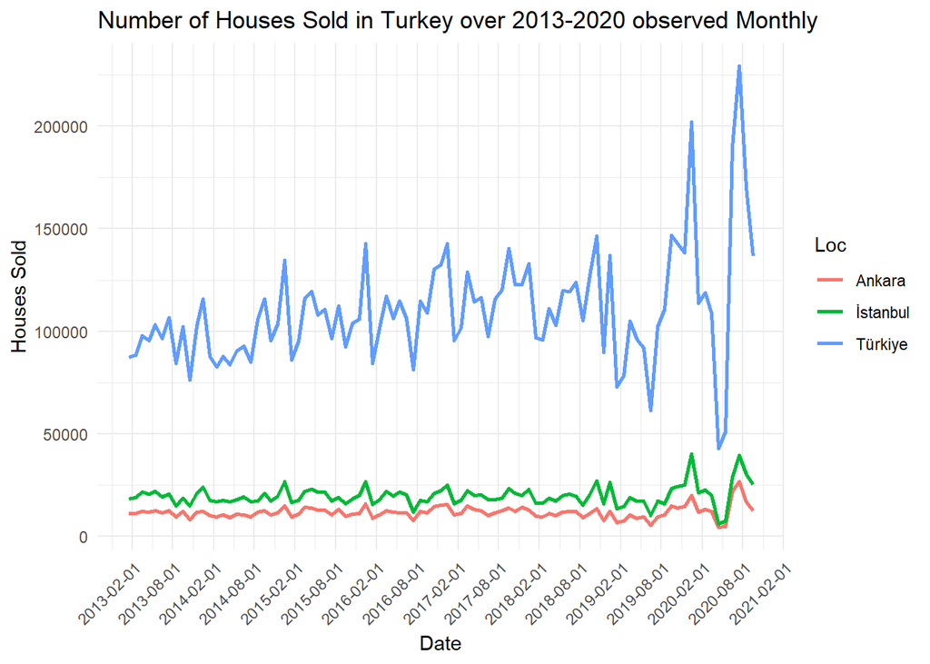

We can see that there are oscillations throughout the time. The general trend seems to be somewhat increasing. It can also be seen that the trends in İstanbul and Ankara show a great deal of parallel to Turkey. In fact, the spikes in these cities are clearer to be understood than Turkey. In most of the past years, there can be seen an increase in number of houses sold in autumn months that eventually resulted in a greater spike in December. However, followed by this increase there seems sudden decreases in the number of houses sold in January. This pattern seems to be repeating over 2013 till 2019 with changing amplitudes. These can be results of housing interests, credits or regulations that start in at the beginning of each year. Apart from these two cities, there also can be detected sharp spikes in spring and summer in Turkey. This may be due to the fact that people preferring to buy summer houses for vocational purposes in cities with beaches. The fact that this trend was not seen in İstanbul and Ankara is supporting this hypothesis, thought it needs further investigation.

If we observe the year by year histograms each constitute of 12 observations,

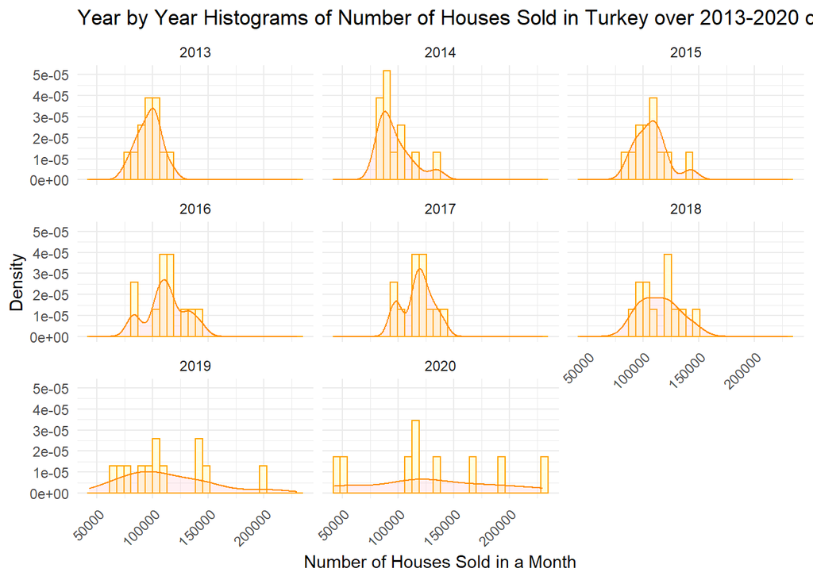

It can be seen that in the first few years the distribution can more easily be fitted into the normal distribution. As the time has passed, the distributions seem to be shifted to the right, showing the increasing trend in number of houses sold. In the past two years, the number range has become wider and the fitting curve is almost flat. This is also in line with the sudden increases and decreases in the number.

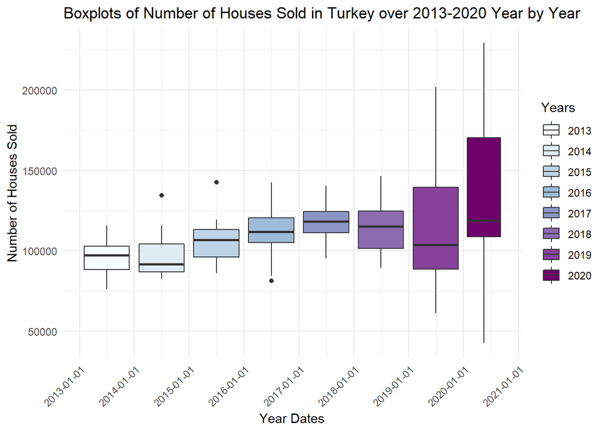

With the boxplot, the story behind the numbers can be seen more clearly. It is obvious that until 2018, there has been a slightly increasing trend in the housing market. However, in the last three years the numbers have become more spread and the increasing trend seems to come to an end. It is only in this year that the market have recovered from that point. Still, the wide range of numbers point to an instability in the market and the reasons behind this phenomena can further be investigated.

As Google Trends search keywords “satılık” and “emlak” is selected. “Satılık” means “for sale” in Turkish. It is a widely used word in internet searches when people are looking for home. “Emlak” means “real estate agency”. The data provided by Google Trends for this keyword was also monthly. When the data is plotted in boxplot,

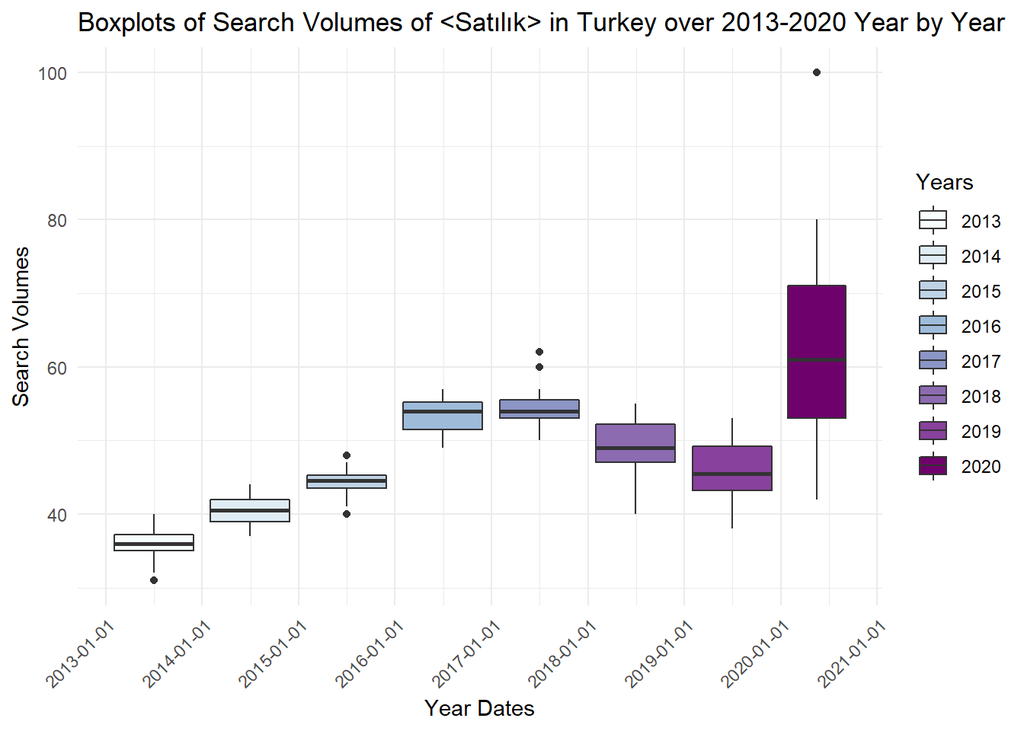

It can be easily observed that the search volume of the word “satılık” is positively correlated with the number of houses sold in Turkey. The movements and changes in range are quite alike. It is only sometimes that the changes in the volume are more obvious than the changes in number of houses sold. This may be due to the fact that “for sale” keyword is used for many other assets such as cars, land etc. So this keyword may represent a more general area of transactions in Turkey economy.

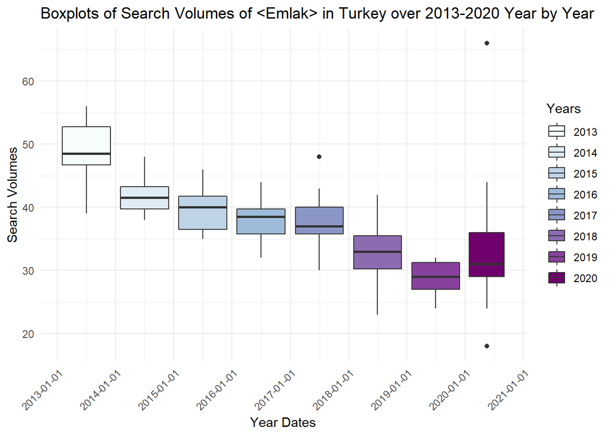

The keyword “emlak” does not seem to show much correlation to the number of houses sold in Turkey over years. In fact, there seems an ever-going decrease in the search volume that continued with movements similar to the last years’ movements in the number of houses sold. The decreasing trend is mysterious and it might be due to the changing preferences of people buying houses since nowadays the web-sites and applications serving for this purpose are used widely.

This measure’s dataset consists of monthly reported values of total number of tourists coming to Turkey in the specified month. The data is collected over the years 2012-2020. The details and preference of chosen date are the same as the first measure set. The data is taken from the [TUIK web-site source](https://data.tuik.gov.tr/Kategori/GetKategori?p=Egitim,-Kultur,-Spor-ve-Turizm-105).

With the necessary manipulations the head of the data frame,

```
##   Year Month Tourists       Date
## 1 2012     1  1374400 2012-01-15
## 2 2012     2  1209064 2012-02-15
## 3 2012     3  1635696 2012-03-15
## 4 2012     4  2231942 2012-04-15
## 5 2012     5  3194546 2012-05-15
## 6 2012     6  3896970 2012-06-15
```

If we plot the observations with respect to time,

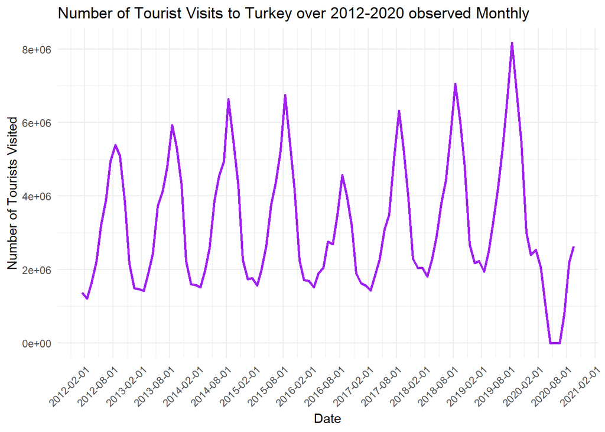

It can easily be seen that there is a high extent of seasonality in the data. There are more tourists coming in the summer months and Turkey is the least attractive for the tourists in winter months. This kind of pattern is just like the average temperatures seen in Turkey. As a result, it can be claimed that what makes Turkey a tourist attraction can be milder temperatures, fresh air and summer vibes around the coastlines. There is also an increasing trend that is broken by the year 2016. This exception to the rule might be because of the tense Turkey and Russian diplomatic relations and the air the failed coup attempt in July 20016 created in Turkey. The crash followed by a weak increase in 2020 is surely the result of lockdown and pandemic.

To look at the trends within years we can plot each year by a different line with respect to months,

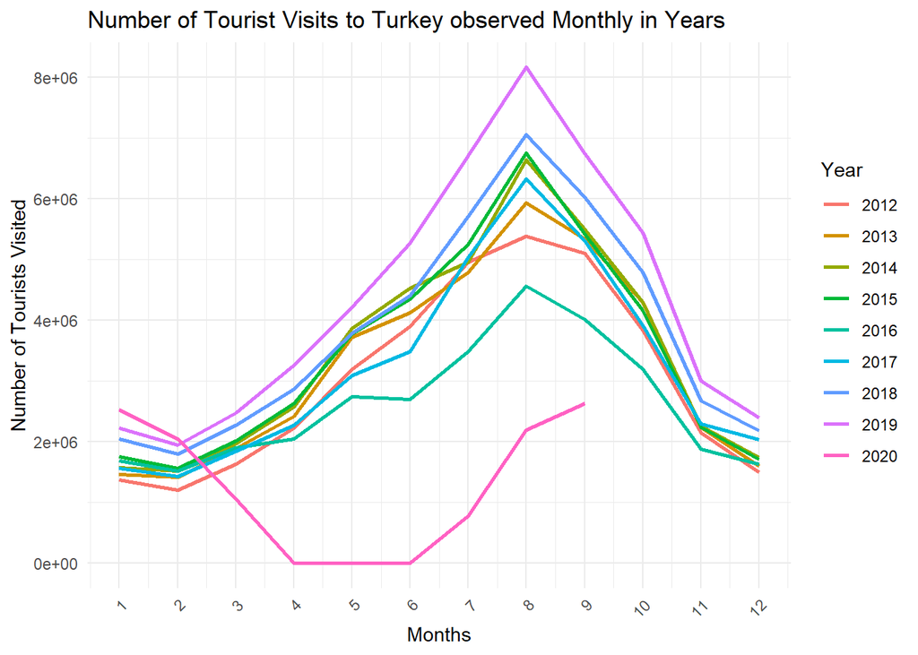

This plot shows that in the last years, the patterns between months have become more and more profound. Moreover, judging from the first two months the year 2020 have signaled the higher tourists coming. It can also be seen that year 2016 started as a normal year but starting from April the numbers did not grow as much as can be expected, this was when the diplomatic relations were the tensest. Consequently, that suggests the earlier idea of why the numbers have dropped in 2016.

If we draw histograms,

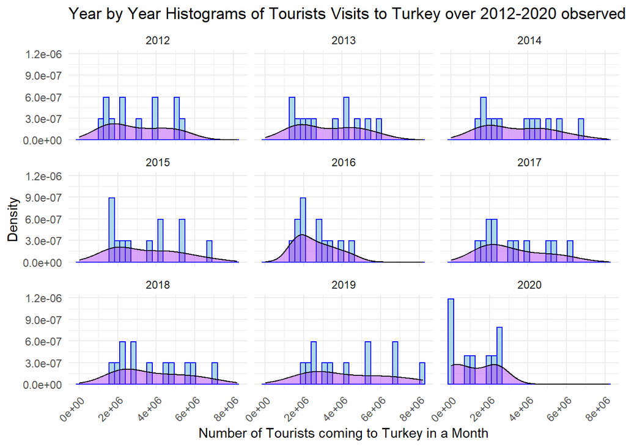

The monthly number of coming tourists are very spread throughout the months in almost all years. As the years go by, it seems that the bins have slightly shifted to right indicating an increase in most of the months.

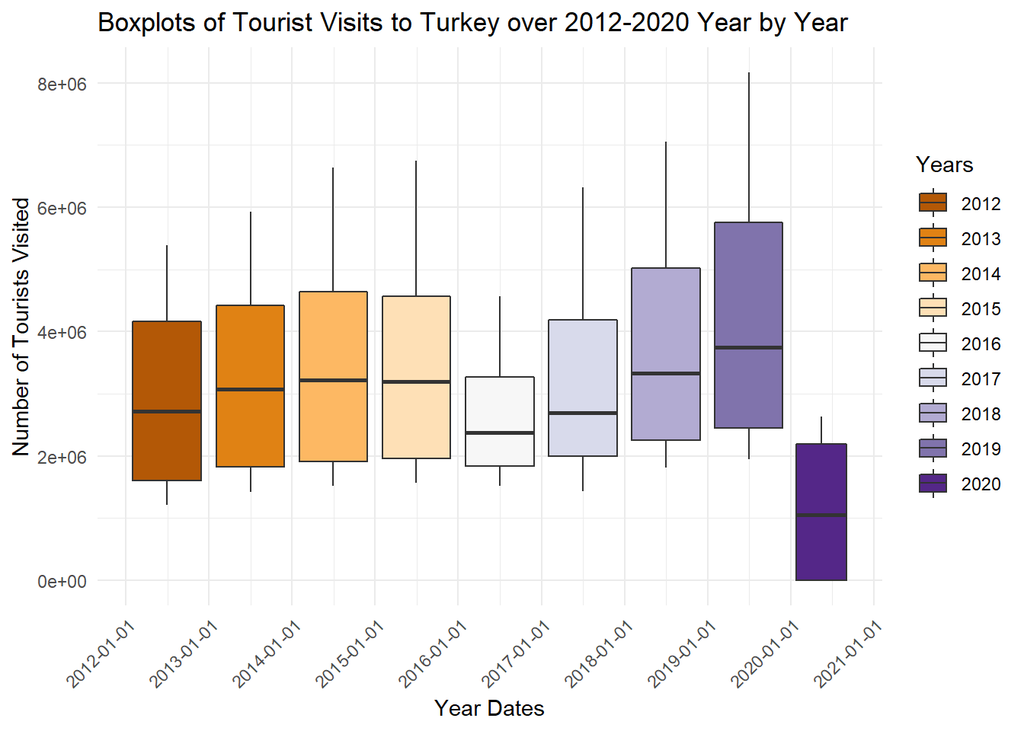

By drawing the box-plots, the previous results can be drawn. If we draw the boxplots of monthly search volumes of some of the famous holiday resorts in Turkey such as Antalya, Bodrum and Çeşme;

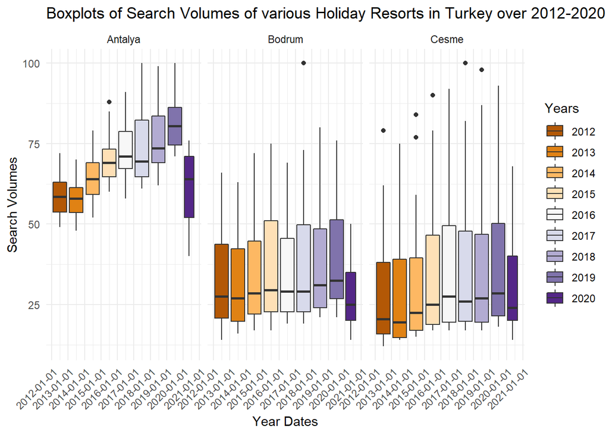

It can be seen from these graphs that despite all other things, Antalya is still more famous and known more widely than the other two important holiday locations. Moreover, the changes in number of tourists can be more easily seen in the changes of search volume of Antalya throughout the time. In addition to these, the search volume of “Çeşme” is wider than the other two locations. This may indicate a pattern where the interest in the city changes substantially over time with seasons.

## 3) Weekly Closing Prices of PETKM Stocks over March 2018 - September 2020

This measure’s dataset includes weekly closing prices of PETKM stocks over March 2018 till September 2020. PETKM is a private company that makes production using petroleum, natural gas and other chemically similar substances. These substances are important for the Turkish industry just like many other countries over the world. However, since there are not much of the sources in the lands of Turkey, this is a huge problem that is frequently discussed. As a consequence, it might be an interesting idea to investigate the stocks of PETKM over time.

Because of the financial data having very unique qualities and high volatility, the selected data collection horizon for this measure is weekly. To perform easier operations, the total time horizon is selected to be shorter than other measures as March 2018 till September 2020. The data is gethered from [investing.com source](https://tr.investing.com/equities/petkim-historical-data).

After the required manipulations on the dataset,

```
##         Date lastPrice Interval
## 1 2018-03-04     5.372        1
## 2 2018-03-11     5.473        1
## 3 2018-03-18     5.412        1
## 4 2018-03-25     5.493        1
## 5 2018-04-01     5.399        1
## 6 2018-04-08     5.135        1
```

The interval is added to facilitate the partition of the data into smaller sets. There are 6 partitions in the set each of which constitute of 5 consecutive months’ data. If we plot the stock prices,

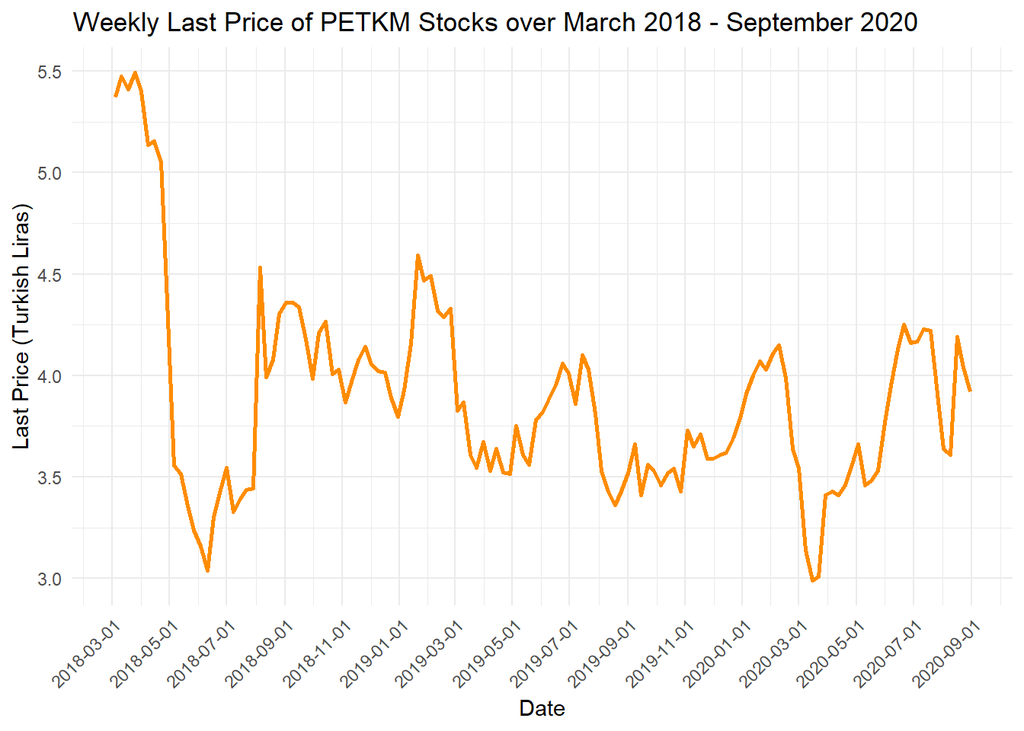

It can be seen that there is a high extent of volatility in the prices throughout these 30 months. There is a decreasing trend started by a sharp fall in April 2018. After that, although at some points the prices seem to go up the trend prevails. The sharp increase at July 2018 might be linked to the rise in prices of natural gas. Whereas, the decrease in March 2019 can be related to extraction of petroleum news in Turkey. There are very ups and downs and these patterns can be result of a lot of complex situations, news and other human perceptions. All in all, it is not easy to explain the economic phenomena.

Starting from 2020, the stock prices seem to be recovering from their decreasing trend. However, the sharp decrease in late February and March may be related to international economy shutting down because of the pandemic situation. In spite of this, the prices have increased just after that so it might be that the pandemic has triggered a sudden need in one or more of the products that PETKM produces. One last comment can be about the increase in prices in late August 2020. These increase is possibly the result of Turkey finding natural gas in Black Sea.

The movements in stock prices is a complex concept that can be partly explained by mathematical equations. However, these are well beyond the scope of this work.

Before moving on with the histograms, it might be a good idea to look at the dates where partitions occur,

```
## [1] "2018-03-04" "2018-08-02" "2019-01-01" "2019-06-02" "2019-10-31"
## [6] "2020-03-31" "2020-08-30"
```

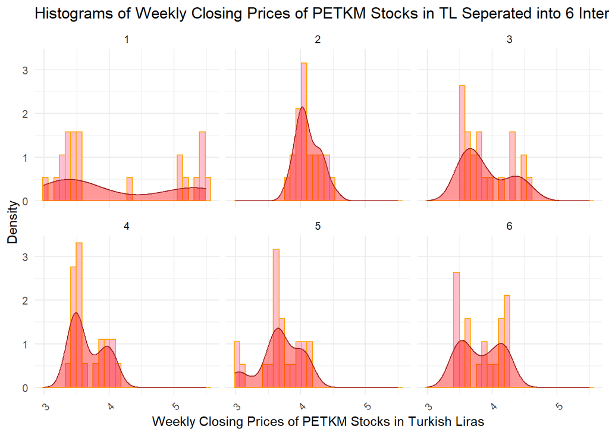

From these visualizations, it can be seen that at least one huge change in prices took place in the first interval. After that point, the weekly closing prices are closer to each other in other time horizons. Through the second, third, fourth and fifth intervals; the minimum and maximum values tend to decrease so it can be said that the stocks of the company did not perform well. In the last interval, the distribution is a little different than the previous ones with two highly frequent values on each end.

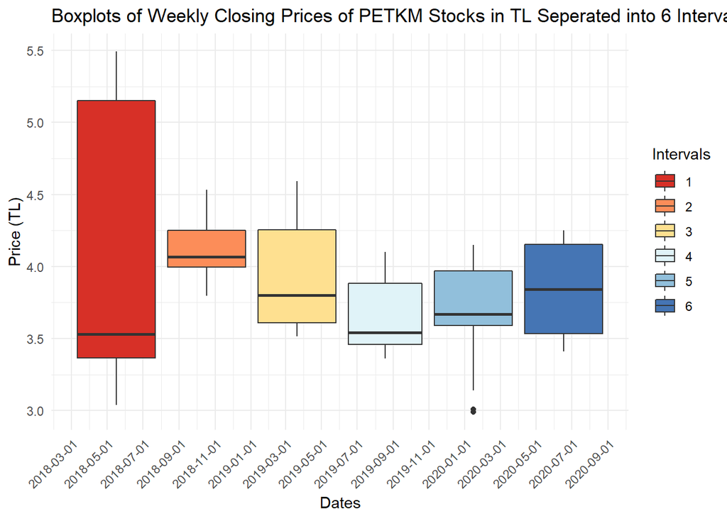

From the boxplots, same ideas can be drawn. There is a wide range of values for the first interval. For the next intervals, values are closer to each other indicating stability. The decreasing trend in the prices seem to continue till the last interval with fifth interval having higher mean but longer down tail and an outlier value. The last interval has wider range of prices with higher mean and probably more instability.

For this measure the word selected on Google Trends were “petroleum” and the company’s own name “PETKM”. If we draw the box plots with weekly values partitioned over the same intervals,

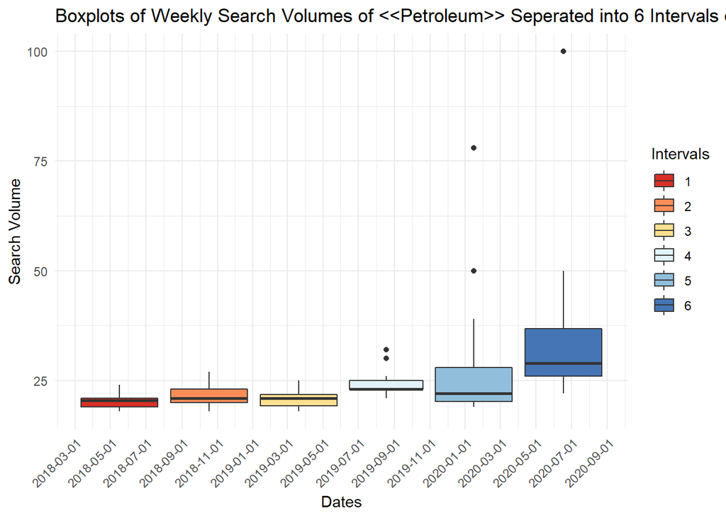

It can be seen that for a long time, the search volume for “petroleum” has been stagnant in a narrow range. With the year 2020 however, there is an increase in the search volumes accompanied by higher outliers. These increases might be related to rise and drop in the national prices or other global news, newly formed trade regulations etc. The increase in the last interval can be the result of Turkey finding natural gas, another likely substance that is used for similar purposes. Still, the movements in the search volume does not bear much relation to the stock prices of PETKM.

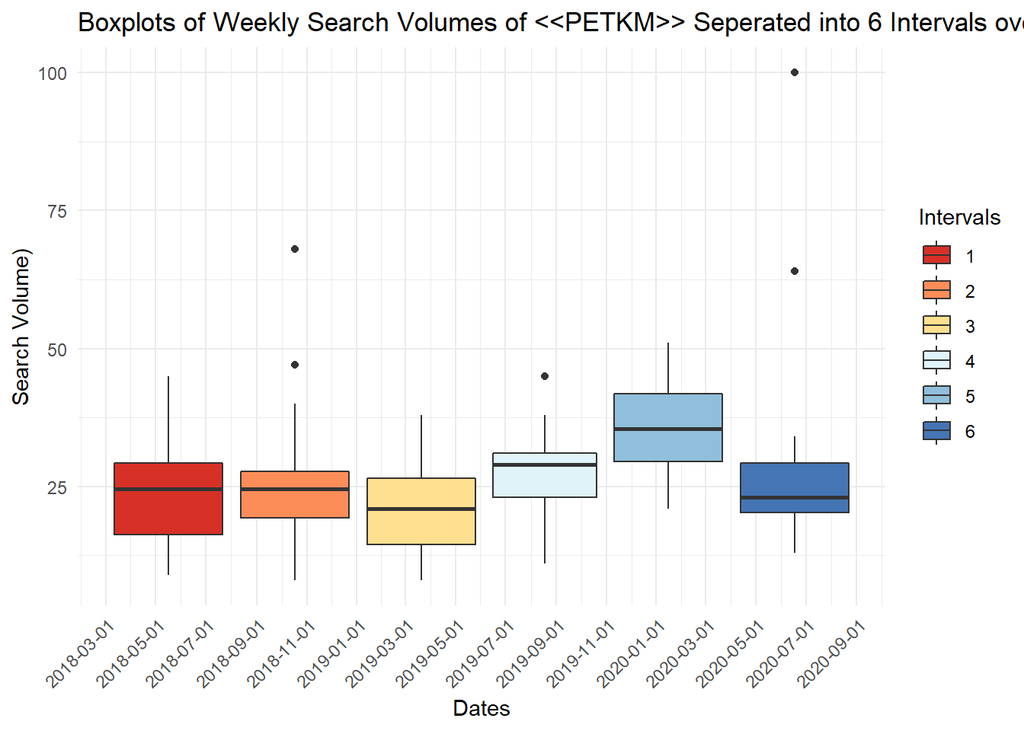

The search volumes of “PETKM” are shown to be stagnant too. In the fourth and fifth intervals there are increases in the search volume that are followed by a decrease with huge outliers. The changes in search volumes do not show any parallel to the closing prices. However, outliers may indicate higher demand and as a result higher stock prices. Although, more detail and knowledge is needed to reach a clear conclusion.

# For the code and RMD document of this report [click.](https://bu-ie-360.github.io/fall20-nilufercetin/files/360Hmw1.Rmd)

## References

[TUIK Web Site](https://data.tuik.gov.tr/) • [Investing.com](https://tr.investing.com/) • [R lubridate Cheat Sheet](https://evoldyn.gitlab.io/evomics-2018/ref-sheets/R_lubridate.pdf) • [Data Visualization](http://www.sthda.com/english/) • [Other Questions](https://stackoverflow.com/)